# 6-renko

```python
#importa as bibliotecas

import pandas as pd
from matplotlib import pyplot as plt
import numpy as np

import yfinance as yf
import statsmodels.api as sm
from datetime import datetime

from sklearn.linear_model import LogisticRegression
from sklearn.model_selection import train_test_split
from sklearn.metrics import RocCurveDisplay
from sklearn.metrics import classification_report
```

## Análise de Renko por Probabilidades

Os blocos **Renko Heikin-Ashi** combinam duas técnicas distintas de representação gráfica de séries financeiras:

- **Renko**, que filtra pequenas oscilações de preço ao registrar apenas movimentos superiores a um determinado limiar;
- **Heikin-Ashi**, que suaviza a série de preços por meio de uma média recursiva das velas, reduzindo o ruído de curto prazo.

$$ \begin{aligned} HA_{close,t} &= \frac{O_t + H_t + L_t + C_t}{4},\\ HA_{open,t} &= \frac{HA_{open,t-1} + HA_{close,t-1}}{2},\\ HA_{high,t} &= \max(H_t, HA_{open,t}, HA_{close,t}),\\ HA_{low,t} &= \min(L_t, HA_{open,t}, HA_{close,t}). \end{aligned} $$

$$|P_t - R_k| \geq B.$$

A direção do bloco é definida por

$$d_k = \begin{cases} +1, & P_t - R_k \geq B,\\ -1, & P_t - R_k \leq -B. \end{cases}$$

Como consequência, os blocos são gerados em intervalos de tempo irregulares: períodos de elevada volatilidade produzem blocos com maior frequência, enquanto períodos de baixa volatilidade resultam em intervalos mais longos entre blocos. Assim, a informação temporal deixa de ser uniforme e passa a ser representada pela duração entre blocos consecutivos,

$$\Delta t_k = t_k - t_{k-1},$$

onde $t_k$ corresponde ao instante de formação do $k$-ésimo bloco.

Dessa forma, cada observação da série pode ser representada pelo par

$$ (\Delta t_k, d_k), $$

em que $\Delta t_k$ representa o tempo transcorrido desde o bloco anterior e $d_k \in \{-1,+1\}$ indica a direção (bearish ou bullish) do novo bloco.

Abaixo, temos duas funções geradas por IA. Uma faz o cálculo do Renko de acordo com a definição e a outra apenas gera o gráfico. Também podemos fazer um exemplo.

```python
def calcular_renko(df, brick_size, price_col='Close'):
    """
    Calcula a série temporal Renko a partir de um DataFrame OHLC.

    Parâmetros:
    - df: DataFrame do Pandas com DatetimeIndex e coluna de preços.
    - brick_size: float, tamanho do tijolo (variação mínima de preço).
    - price_col: string, nome da coluna de referência (padrão 'Close').

    Retorno:
    - DataFrame com o OHLC do Renko, Direção (1 para alta, -1 para baixa) e Duração.
    """

    # Validação inicial
    if price_col not in df.columns:
        raise ValueError(f"A coluna '{price_col}' não foi encontrada no DataFrame.")

    renko_blocks = []

    # Inicializando as referências com o primeiro preço
    primeiro_preco = df[price_col].iloc[0]
    ultimo_tempo = df.index[0]

    # Mantém o topo e o fundo do último bloco de referência
    prev_brick_high = primeiro_preco
    prev_brick_low = primeiro_preco
    direcao_atual = 0  # 1 para alta, -1 para baixa, 0 para inicial

    for tempo, row in df.iterrows():
        preco_atual = row[price_col]

        # O while trata casos de movimentos muito fortes que formam múltiplos tijolos de uma vez
        while True:
            # Condição de Alta
            if preco_atual >= prev_brick_high + brick_size:
                # Se estava em baixa, o open do novo tijolo é o topo do tijolo anterior.
                # Se estava em alta (ou início), o open é o topo atual.
                b_open = prev_brick_high if (direcao_atual == 1 or direcao_atual == 0) else prev_brick_low + brick_size
                b_close = prev_brick_high + brick_size

                duracao = tempo - ultimo_tempo

                renko_blocks.append({
                    'Date': tempo,
                    'Open': b_open,
                    'High': b_close,
                    'Low': b_open,
                    'Close': b_close,
                    'Direction': 1,
                    'Duration': duracao
                })

                # Atualiza referências
                prev_brick_low = b_open
                prev_brick_high = b_close
                direcao_atual = 1
                ultimo_tempo = tempo

            # Condição de Baixa
            elif preco_atual <= prev_brick_low - brick_size:
                # Se estava em alta, o open do novo tijolo é o fundo do tijolo anterior.
                b_open = prev_brick_low if (direcao_atual == -1 or direcao_atual == 0) else prev_brick_high - brick_size
                b_close = prev_brick_low - brick_size

                duracao = tempo - ultimo_tempo

                renko_blocks.append({
                    'Date': tempo,
                    'Open': b_open,
                    'High': b_open,
                    'Low': b_close,
                    'Close': b_close,
                    'Direction': -1,
                    'Duration': duracao
                })

                # Atualiza referências
                prev_brick_high = b_open
                prev_brick_low = b_close
                direcao_atual = -1
                ultimo_tempo = tempo

            else:
                # Movimento não foi suficiente para formar um novo tijolo
                break

    # Cria o DataFrame final
    df_renko = pd.DataFrame(renko_blocks)

    # Se gerou blocos, configura o índice de tempo
    if not df_renko.empty:
        df_renko.set_index('Date', inplace=True)

    return df_renko
```

```python
def plotar_renko(df_renko):
    """
    Plota o gráfico de Renko a partir do DataFrame gerado.

    Parâmetros:
    - df_renko: DataFrame contendo as colunas Open, Close, Direction e o índice de tempo.
    """

    if df_renko.empty:
        print("O DataFrame de Renko está vazio. Não há o que plotar.")
        return

    # Cria a figura
    fig, ax = plt.subplots(figsize=(14, 7))

    # Eixo X sequencial (cada bloco fica lado a lado, ignorando saltos de tempo)
    x_pos = range(len(df_renko))

    # Separando os índices e dados para Blocos de Alta (Verdes) e Baixa (Vermelhos)
    altas = df_renko['Direction'] == 1
    baixas = df_renko['Direction'] == -1

    idx_altas = [i for i, val in enumerate(altas) if val]
    idx_baixas = [i for i, val in enumerate(baixas) if val]

    # Calculando a altura dos blocos (absoluta)
    # Na alta: Close - Open. Na baixa: Open - Close.
    alturas_altas = df_renko.loc[altas, 'Close'] - df_renko.loc[altas, 'Open']
    alturas_baixas = df_renko.loc[baixas, 'Open'] - df_renko.loc[baixas, 'Close']

    # Plotando os blocos como barras
    # bottom = o ponto mais baixo do corpo do tijolo
    ax.bar(idx_altas, alturas_altas, bottom=df_renko.loc[altas, 'Open'],
           color='#2ca02c', edgecolor='black', width=0.9, label='Alta')

    ax.bar(idx_baixas, alturas_baixas, bottom=df_renko.loc[baixas, 'Close'],
           color='#d62728', edgecolor='black', width=0.9, label='Baixa')

    # Estilização do Gráfico
    ax.set_title("Gráfico Renko Ashi", fontsize=16, fontweight='bold')
    ax.set_ylabel("Preço", fontsize=12)
    ax.set_xlabel("Evolução (Data de Formação do Bloco)", fontsize=12)
    ax.grid(axis='y', linestyle='--', alpha=0.7)

    # Configurando os rótulos do eixo X para exibir as datas
    # Mostramos cerca de 10 datas espaçadas para não poluir o gráfico
    step = max(1, len(df_renko) // 10)
    x_ticks = list(range(0, len(df_renko), step))

    # Extrai as datas do índice, formata e aplica ao gráfico
    x_labels = [df_renko.index[i].strftime('%Y-%m-%d %H:%M') for i in x_ticks]
    ax.set_xticks(x_ticks)
    ax.set_xticklabels(x_labels, rotation=45, ha='right')

    # Adicionando legenda e ajustando o layout
    ax.legend(loc='upper left')
    plt.tight_layout()

    # Exibe o gráfico
    plt.show()

    return fig,ax
```

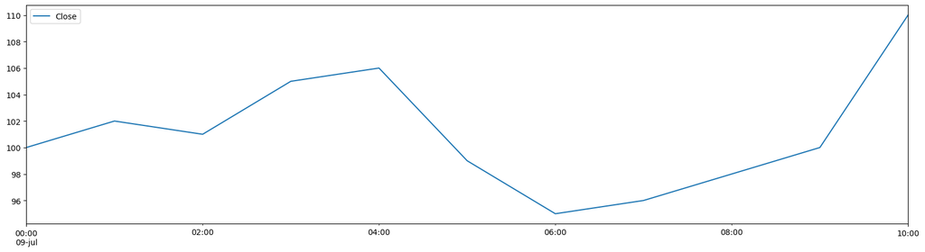

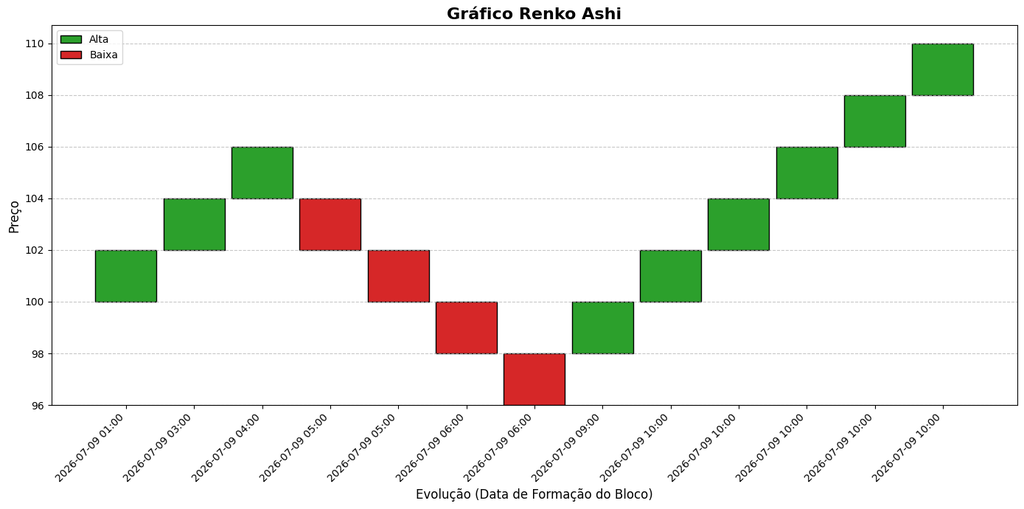

```
(<Figure size 1400x700 with 1 Axes>,
 <Axes: title={'center': 'Gráfico Renko Ashi'}, xlabel='Evolução (Data de Formação do Bloco)', ylabel='Preço'>)
```

```python
# ==========================================
# Exemplo de Uso Prático
# ==========================================

# Criando dados fictícios em um Pandas DataFrame
datas = pd.date_range(start='2026-07-09', periods=11, freq='h')
precos = [100, 102, 101, 105, 106, 99, 95, 96, 98, 100,110]

df_ohlc = pd.DataFrame({'Close': precos}, index=datas)

# Chamando a função (Tamanho do tijolo = 2)
tamanho_tijolo = 2.0
renko_df = calcular_renko(df_ohlc, brick_size=tamanho_tijolo, price_col='Close')
df_ohlc.plot(figsize=(20,5))

plotar_renko(renko_df)
```

```
[*********************100%***********************]  1 of 1 completed
```

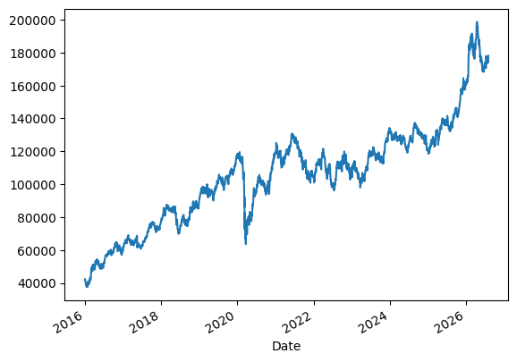

```python
# a partir do yfinance, tira os dados do IBOV de jan/16 até hoje. vc pode controlar este intervalo

start_date = datetime(2016,1,1)
end_date = datetime.today()

ticker = "^BVSP"

dataset = yf.download(
    ticker,
    start=start_date,
    end=end_date,
    auto_adjust=False,
    interval="1d"
    ).droplevel(axis=1,level=1)

dataset["Close"].plot()
```

Em seguida, temos um pré-processamento de teste. Devido ao fato de que o preço dos ativos tende a crescer ao longo do tempo (e por isso as pessoas ficam compradas em índices a longo prazo), acabamos por ter uma distorção das flutuações que ocorrem em torno da "média" deste crescimento.

Por isso, para resolver isto e analisar apenas as flutuações de médio prazo, subtraímos todos os dados de uma média de fechamento de 1 ano útil.

Outras ideias aqui: utilizar um filtro de Kalman (mas não deve gerar tanta diferença assim)

```python
mu = dataset.Close.ewm(span=252).mean()

Z = (dataset[["Close","Open","High","Low"]].sub(mu,axis=0))
```

Então, calculamos o renko sobre a flutuação $Z$ de médio prazo:

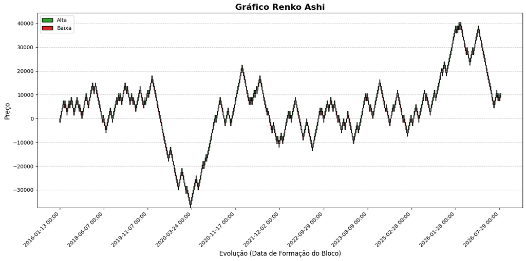

```
(<Figure size 1400x700 with 1 Axes>,
 <Axes: title={'center': 'Gráfico Renko Ashi'}, xlabel='Evolução (Data de Formação do Bloco)', ylabel='Preço'>)
```

```python
renko_base = calcular_renko(Z, 1500, price_col='Close')

plotar_renko(renko_base)
```

Esse valor de 1500 é arbitrário. Você pode trocá-lo. O ponto será que o renko detectará a variação que você colocar neste campo. Vamos chamar este campo de $\delta$.

Posteriormente avaliamos a distribuição dos valores de duração. É possível notar que eles formam uma distribuição exponencial.

O ponto disto é avaliar que, o tempo de permanência em um bloco tem uma distribuição de probabilidade exponencial. Isto implica que, quanto mais tempo um bloco passa sem variar $\delta$ maior a probabilidade dele variá-lo (devido a CDF da dist. exp.).

Esta duração no bloco, chamaremos de $\Delta t$.

### Aqui vale a pena testar um QQ-plot ou um KS com uma exponencial mesmo.

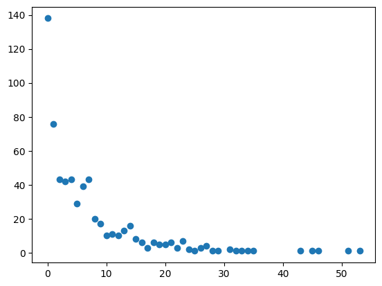

```python
values_on_count = renko_base["Duration"].dt.days.value_counts()
plt.scatter(values_on_count.index,values_on_count.values)
```

Aqui eu testei algumas features. O ponto geral do modelo é responder a seguinte pergunta:

$$ \begin{aligned} P(D_k|D_{k-1},\Delta t_{k},\delta) = ? \end{aligned} $$

Qual a probabilidade da próxima direção, dado a direção anterior, a duração do bloco atual (que ainda não se resolveu, não fechou, não foi definido) e $\delta$?

Aqui é possível brincar com as features e testar. Mas o importante é considerar o valor anterior e a variação do tempo.

Se avaliarmos apenas $P(D_k|D_{k-1})$, o problema se transforma em uma cadeia de Markov de 1a ordem.

```python
renko_base["int_dur"] = renko_base["Duration"].dt.days
renko_base["log_dur"] = renko_base["int_dur"].apply(np.log1p)
renko_base["state"] = renko_base["Direction"].shift(1)
renko_base["inter"] = renko_base["state"]*renko_base["log_dur"]

renko_base.dropna(inplace=True)
```

```
<sklearn.metrics._plot.roc_curve.RocCurveDisplay at 0x1c3a667f710>
```

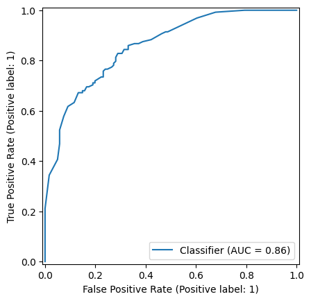

```python
X = renko_base[["state","int_dur","inter"]]
y = renko_base["Direction"]


#o split dos dados é feito de tal forma a não contaminar o modelo com informações futuras.
split = int(0.6 * len(X))

X_train = X.iloc[:split]
X_test  = X.iloc[split:]

y_train = y.iloc[:split]
y_test  = y.iloc[split:]

model = LogisticRegression()

model.fit(X_train,y_train)

y_predict = model.predict(X_test)

RocCurveDisplay.from_predictions(y_test,model.predict_proba(X_test)[:,1])
```

Aqui os resultados parecem bons. Não parei para pensar no que é melhor: precisão ou recall? Não sei o que daria mais prejuízo.

```python
print(classification_report(y_test,y_predict))
```

```
              precision    recall  f1-score   support

          -1       0.75      0.76      0.76       121
           1       0.77      0.77      0.77       128

    accuracy                           0.76       249
   macro avg       0.76      0.76      0.76       249
weighted avg       0.76      0.76      0.76       249
```

A entropia estatística $H$ é uma maneira de avaliar o quanto o modelo conseguiu concluir alguma coisa sobre a predição.

Ela é definida como:

$$ \begin{aligned} H = \frac{1}{log(n)} \sum_{i=0}^{n} - P_i log(P_i) \end{aligned} $$

onde $n$ são os possíveis estados a serem avaliados no espaço de probabilidade (o espaço de coisas possíveis de se acontecer. no nosso problema, ou o bloco do renko vai cair (-1) ou subir (1)).

```python
probs = model.predict_proba(X_test)

H = np.sum(-np.log(probs)*probs,axis=1)/np.log(2)
```

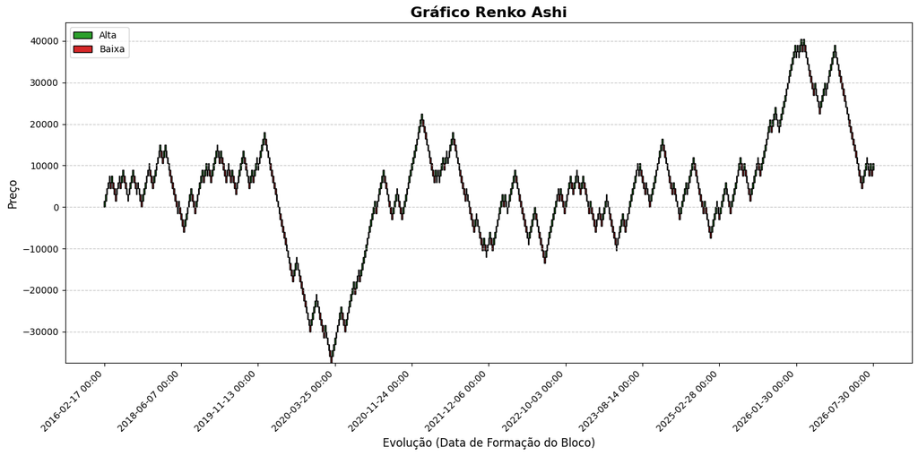

```python
fig,ax = plotar_renko(renko_base)
```

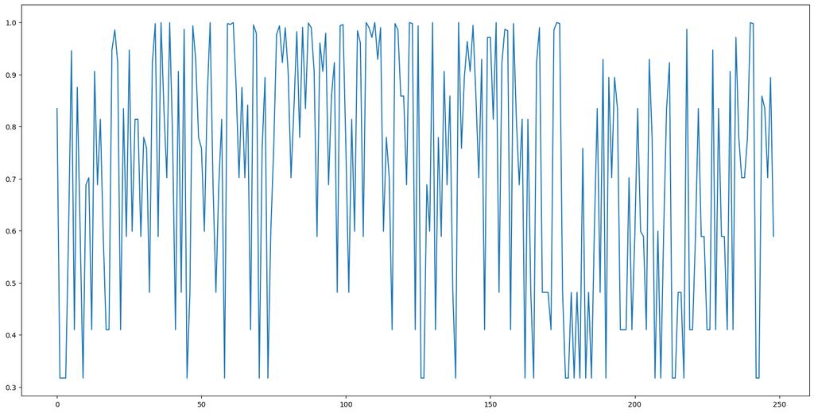

```python
plt.figure(figsize=(20,10))
plt.plot(H)
```

É possível notar que muitas vezes o modelo fica sem concluir nada.

Agora, os próximos passos seriam testar:

- O modelo está com algum tipo de look-ahead bias no processo?
- Este modelo faz sentido?
- Escolhendo um estado e variando o tempo do modelo, como a entropia da previsão neste meio tempo se comporta?
- É possível testar com outro ativo e com outro time-frame? Quais seriam os resultados?
- Seria possível implementar este modelo em produção? Por isso a pergunta da variação da entropia é importante. Enquanto o bloco não fechar, nós não vamos saber quando ele vai fechar.
- Ideia: adicionar a probabilidade da exponencial dos dados como feature.
- Ideia: avaliar os valores SHAP do modelo.
- Digressão: é possível encontrar padrões fractais em $Z$?